# Isis Flag History

### 2026

#### Hilary

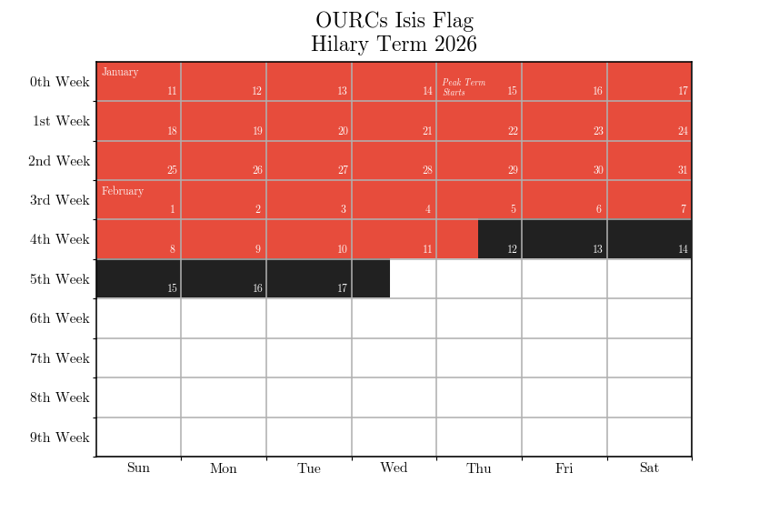

Percentage of Peak Term (2026-01-15 to today) under each flag:

|  | % |
| --- | --- |
| Black | 17.3 |
| Red | 82.7 |
| Amber | 0 |
| Dark Blue | 0 |
| Light Blue | 0 |
| Green | 0 |
| Grey | 0 |

### 2025

#### Michaelmas

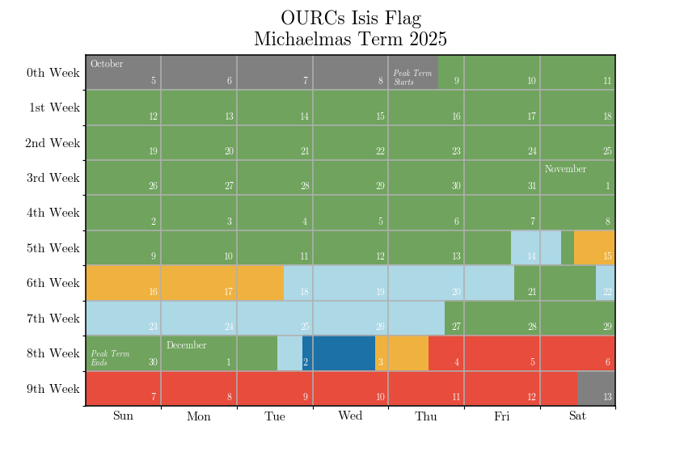

Percentage of Peak Term (2025-10-09 to 2025-11-29 inclusive) under each flag:

|  | % |
| --- | --- |
| Black | 0 |
| Red | 0 |
| Amber | 6.1 |
| Dark Blue | 0 |
| Light Blue | 16.7 |
| Green | 75.9 |
| Grey | 1.3 |

#### Trinity

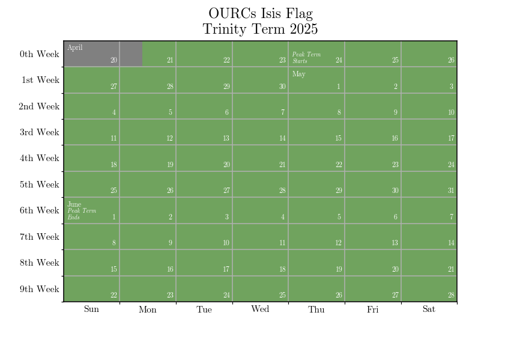

Percentage of Peak Term (2025-04-24 to 2025-05-31 inclusive) under each flag:

|  | % |
| --- | --- |
| Black | 0 |
| Red | 0 |
| Amber | 0 |
| Dark Blue | 0 |
| Light Blue | 0 |
| Green | 100.0 |
| Grey | 0 |

#### Hilary

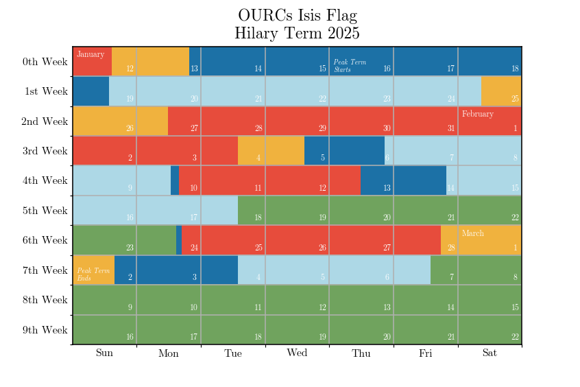

Percentage of Peak Term (2025-01-16 to 2025-03-01 inclusive) under each flag:

|  | % |
| --- | --- |
| Black | 0 |
| Red | 33.2 |
| Amber | 9.8 |
| Dark Blue | 14.2 |
| Light Blue | 29.4 |
| Green | 13.4 |
| Grey | 0 |

### 2024

#### Michaelmas

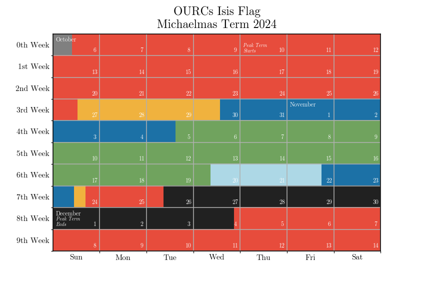

Percentage of Peak Term (2024-10-10 to 2024-11-30 inclusive) under each flag:

|  | % |
| --- | --- |
| Black | 8.9 |
| Red | 36.9 |
| Amber | 6.3 |
| Dark Blue | 14.9 |
| Light Blue | 4.6 |
| Green | 28.4 |
| Grey | 0 |

#### Trinity

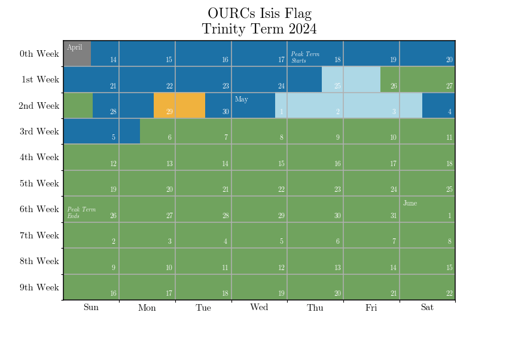

Percentage of Peak Term (2024-04-18 to 2024-05-25 inclusive) under each flag:

|  | % |
| --- | --- |
| Black | 0 |
| Red | 0 |
| Amber | 2.4 |
| Dark Blue | 31.4 |
| Light Blue | 9.6 |
| Green | 56.6 |
| Grey | 0 |

#### Hilary

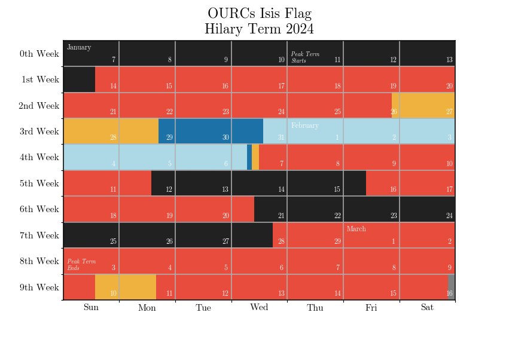

Percentage of Peak Term (2024-01-11 to 2024-03-02 inclusive) under each flag:

|  | % |
| --- | --- |
| Black | 28.4 |
| Red | 49.3 |
| Amber | 5.7 |
| Dark Blue | 3.8 |
| Light Blue | 12.9 |
| Green | 0 |
| Grey | 0 |

### 2023

#### Michaelmas

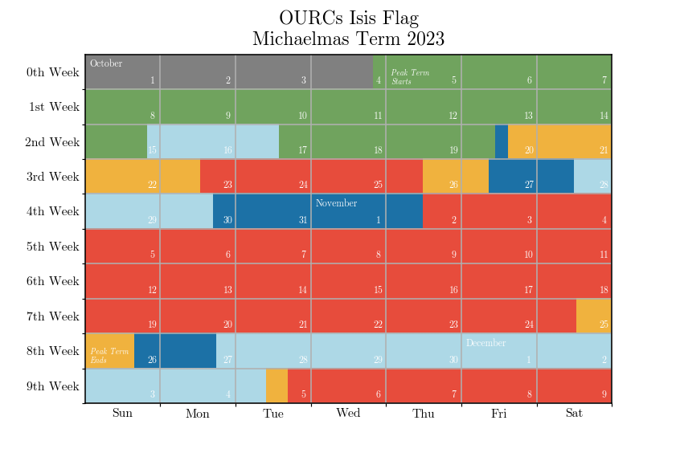

Percentage of Peak Term (2023-10-05 to 2023-11-25 inclusive) under each flag:

|  | % |
| --- | --- |
| Black | 0 |
| Red | 50.0 |
| Amber | 8.2 |
| Dark Blue | 7.9 |
| Light Blue | 7.6 |
| Green | 26.4 |
| Grey | 0 |

#### Trinity

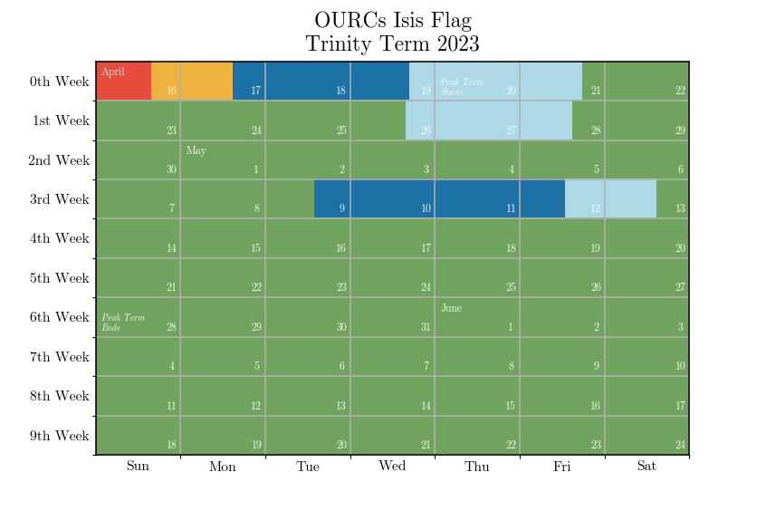

Percentage of Peak Term (2023-04-20 to 2023-05-27 inclusive) under each flag:

|  | % |
| --- | --- |
| Black | 0 |
| Red | 0 |
| Amber | 0 |
| Dark Blue | 7.8 |
| Light Blue | 12.6 |
| Green | 79.6 |
| Grey | 0 |

#### Hilary

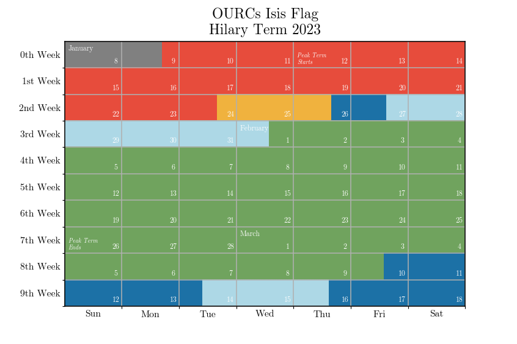

Percentage of Peak Term (2023-01-12 to 2023-02-25 inclusive) under each flag:

|  | % |
| --- | --- |
| Black | 0 |
| Red | 28.1 |
| Amber | 4.4 |
| Dark Blue | 2.1 |
| Light Blue | 11.0 |
| Green | 54.3 |
| Grey | 0 |

## Links

- OURCs’s [Flags](https://ourcs.co.uk/information/flags/isis/)
- Anu Dudhia’s [Isis Level](https://eodg.atm.ox.ac.uk/user/dudhia/rowing/river.html)
- Jameson Lee and Joe Hitchen’s [Isis Flag Differential](https://flags.jamesonlee.com/)
- Arthur Bullard’s guide to [Reading the lock](https://www.photonhunter.co.uk/~art/rowing/bucks.html) at Iffley

*Last updated: 2026-02-18 10:32*